# Assignment II-Busines Analytics

```r
#Question 1
set.seed(2017)
X=runif(100)*10
Y=X*4+3.45
Y=rnorm(100)*0.29*Y+Y

#Question a)
library(dplyr)
```

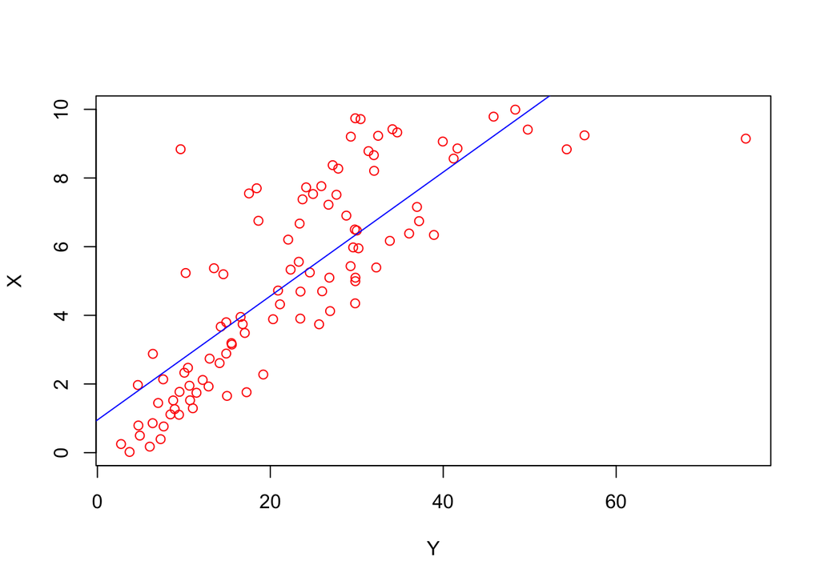

```r
plot(Y,X, col='red')
abline(lsfit(Y,X), col= "Blue")
```

From the above plot with line of best fit we can say that there is a linear and positive relationship between X and Y. Therefore, we can fit linear model to explain Y based on X.

```r
#Question b)

Model=lm(Y~X)
print(Model)
```

```
##
## Call:
## lm(formula = Y ~ X)
##
## Coefficients:
## (Intercept)            X
##       4.465        3.611
```

```r
Equation = 4.465 + 3.611*X
Equation
```

[output not shown]

```r
summary(Model)
```

```
##
## Call:
## lm(formula = Y ~ X)
##
## Residuals:
##     Min      1Q  Median      3Q     Max
## -26.755  -3.846  -0.387   4.318  37.503
##
## Coefficients:
##             Estimate Std. Error t value Pr(>|t|)
## (Intercept)   4.4655     1.5537   2.874  0.00497 **
## X             3.6108     0.2666  13.542  < 2e-16 ***
## ---
## Signif. codes:  0 '***' 0.001 '**' 0.01 '*' 0.05 '.' 0.1 ' ' 1
##
## Residual standard error: 7.756 on 98 degrees of freedom
## Multiple R-squared:  0.6517, Adjusted R-squared:  0.6482
## F-statistic: 183.4 on 1 and 98 DF,  p-value: < 2.2e-16
```

Based on the summary of this equation R-squared = 0.6517. 65% is the accuracy of the model. This means the model explains 65% variability the target variable.

```r
#Question c)
#Answer
#Based on the summary of this equation R2 = 0.6517. 65% is the accuracy of the model. This means the model explains 65% variability the target (response) variable. Therefore, X is a good predictor of the variable Y.
```

```r
#Question d)    Investigate the appropriateness of using linear regression for this case

Model$residuals
```

[output not shown]

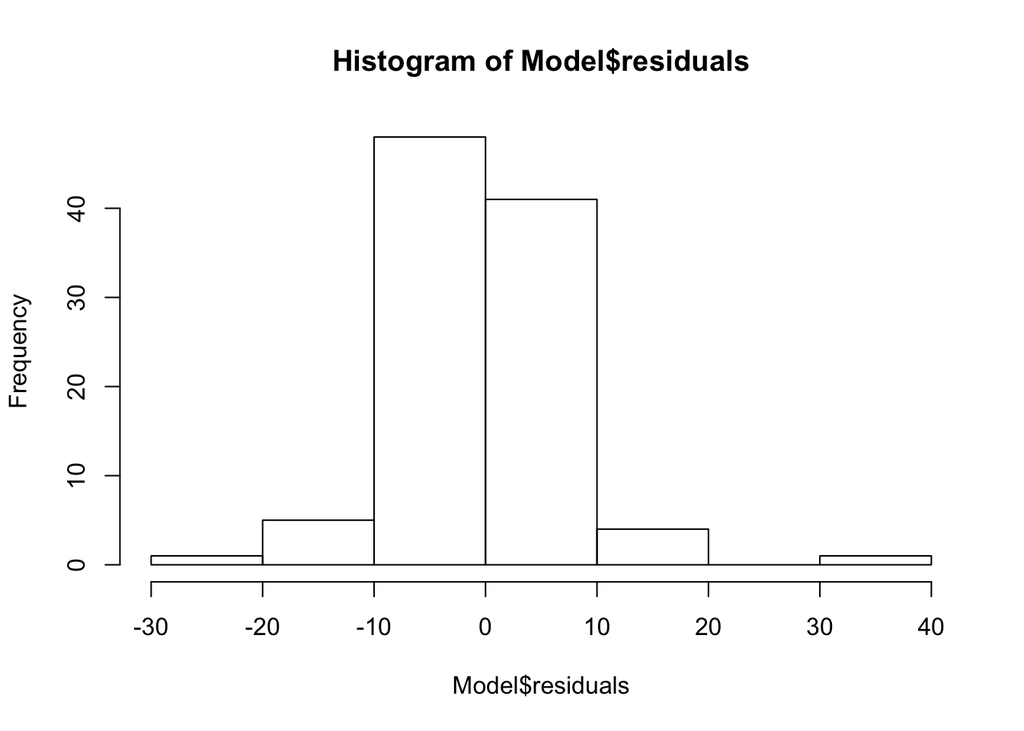

```r
#Histogram of the residuals
hist(Model$residuals)
```

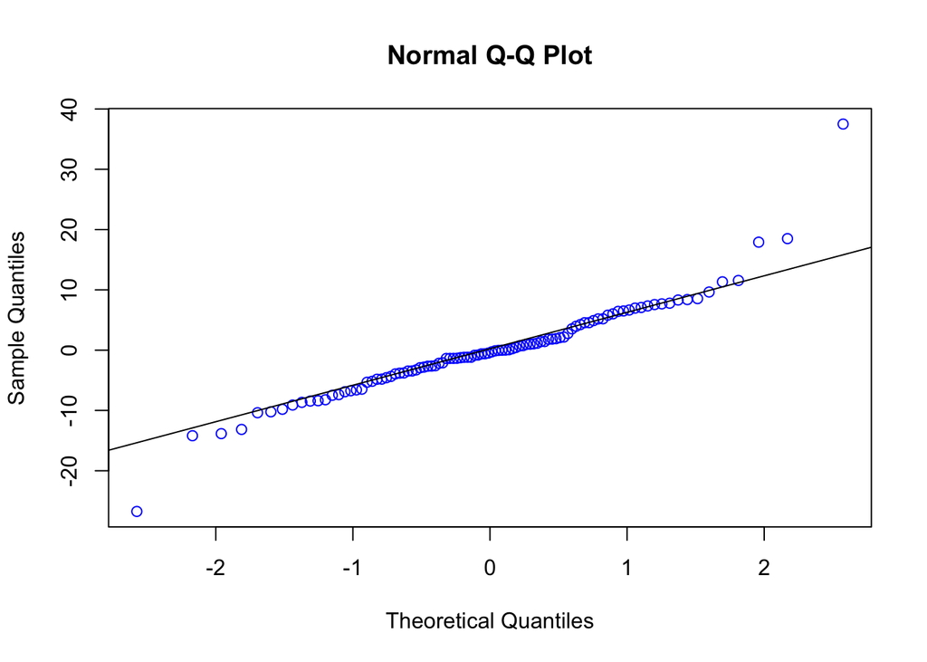

```r
#qqplot Line
qqnorm(Model$residuals, col= "Blue")
qqline(Model$residuals)
```

```r
#Question 2a)
#Linear model based on weight of a car (wt) can be used to estimate the Horse Power

wt <- lm(hp~wt, data = mtcars)
summary(wt)
```

```
##
## Call:
## lm(formula = hp ~ wt, data = mtcars)
##
## Residuals:
##     Min      1Q  Median      3Q     Max
## -83.430 -33.596 -13.587   7.913 172.030
##
## Coefficients:
##             Estimate Std. Error t value Pr(>|t|)
## (Intercept)   -1.821     32.325  -0.056    0.955
## wt            46.160      9.625   4.796 4.15e-05 ***
## ---
## Signif. codes:  0 '***' 0.001 '**' 0.01 '*' 0.05 '.' 0.1 ' ' 1
##
## Residual standard error: 52.44 on 30 degrees of freedom
## Multiple R-squared:  0.4339, Adjusted R-squared:  0.4151
## F-statistic:    23 on 1 and 30 DF,  p-value: 4.146e-05
```

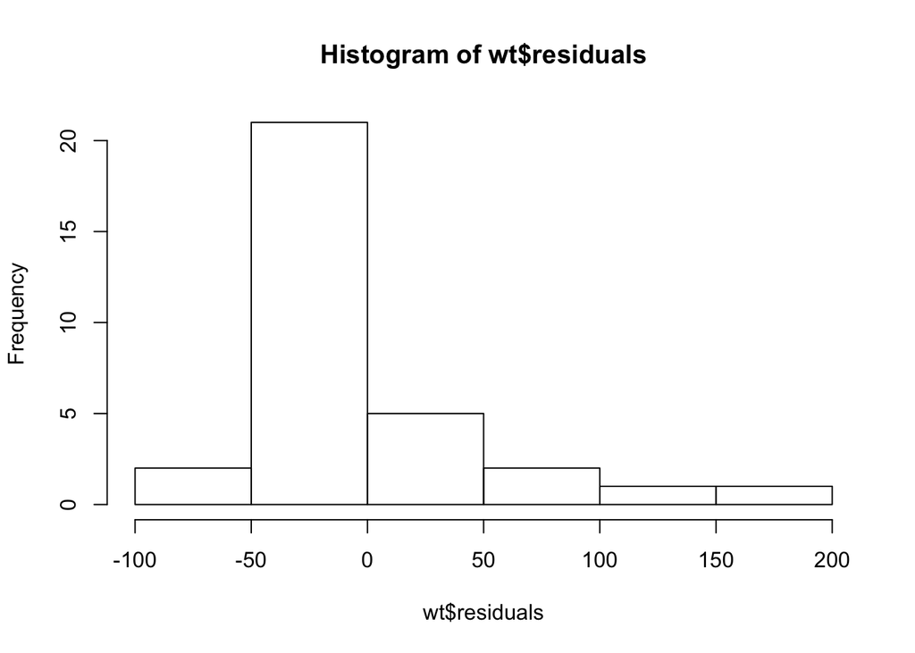

```r
hist(wt$residuals)
```

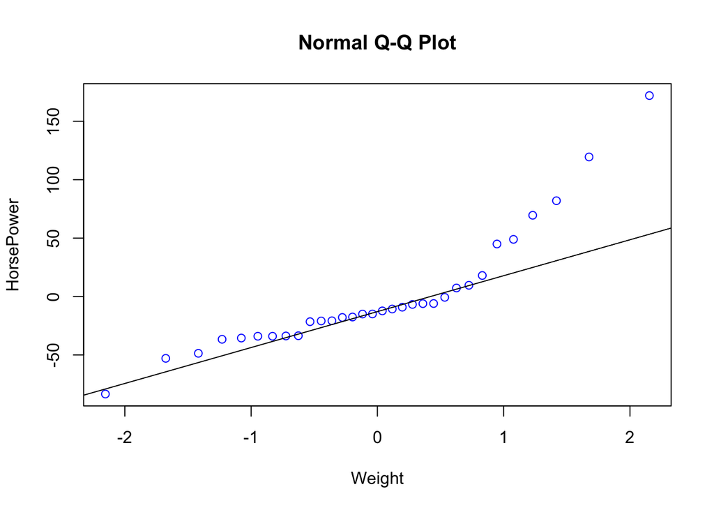

```r
qqnorm(wt$residuals, xlab = "Weight", ylab = "HorsePower", col="Blue")
qqline(wt$residuals)
```

R-squared of this linear model based on weight of a car is 0.4339. Accuracy is 43.39%

```r
#Linear model based on fuel consumption expressed in Mile Per Gallon (mpg) can be used to estimate the Horse Power

mpg <- lm(hp~mpg, data = mtcars)
summary(mpg)
```

```
##
## Call:
## lm(formula = hp ~ mpg, data = mtcars)
##
## Residuals:
##    Min     1Q Median     3Q    Max
## -59.26 -28.93 -13.45  25.65 143.36
##
## Coefficients:
##             Estimate Std. Error t value Pr(>|t|)
## (Intercept)   324.08      27.43  11.813 8.25e-13 ***
## mpg            -8.83       1.31  -6.742 1.79e-07 ***
## ---
## Signif. codes:  0 '***' 0.001 '**' 0.01 '*' 0.05 '.' 0.1 ' ' 1
##
## Residual standard error: 43.95 on 30 degrees of freedom
## Multiple R-squared:  0.6024, Adjusted R-squared:  0.5892
## F-statistic: 45.46 on 1 and 30 DF,  p-value: 1.788e-07
```

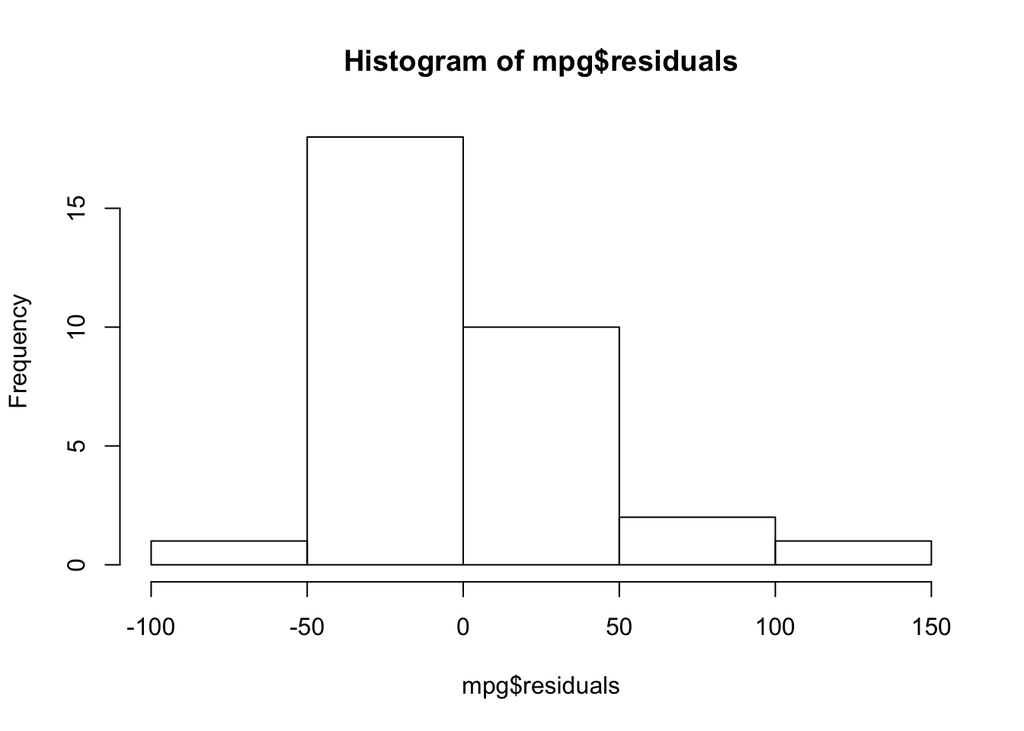

```r
hist(mpg$residuals)
```

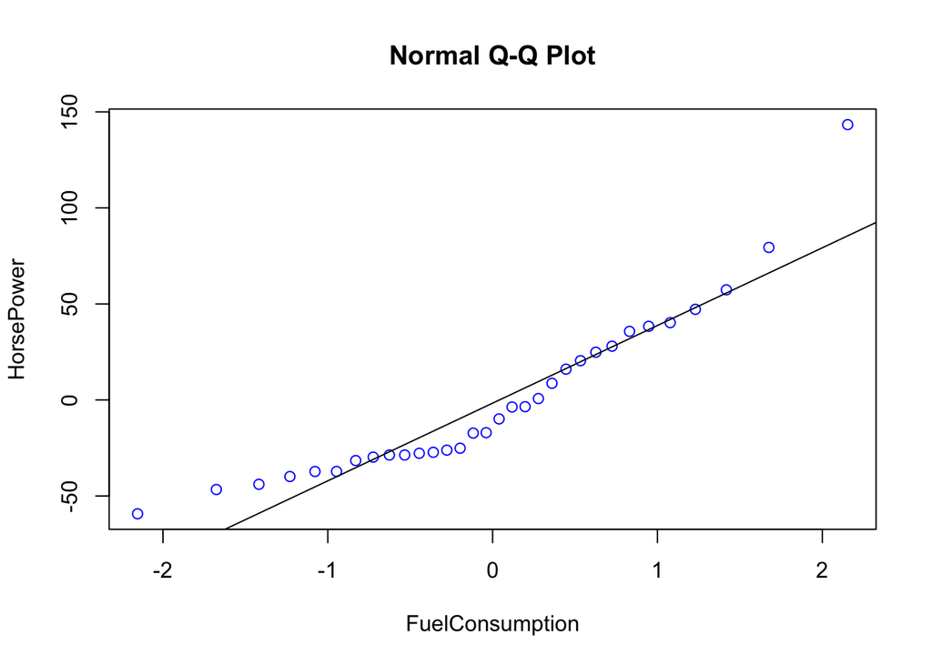

```r
qqnorm(mpg$residuals, xlab = "FuelConsumption", ylab = "HorsePower", col="Blue")
qqline(mpg$residuals)
```

R-squared of this linear model based on fuel consumption expressed in Mile Per Gallon (mpg) is 0.6024. Based on the linear model, histogram and Q-Q Plot indicates that fuel consumption expressed in Mile Per Gallon (mpg) is a better estimator of car horsepower than weight of a car. The accuracy of the mpg model is 60% and that of weight is 43%. Therefore, mpg contributes more towards the predicated horsepower of the car. Therefore, Chris is right.

```r
#Question 2b)
#Build a model that uses the number of cylinders (cyl) and the mile per gallon (mpg) values of a car to predict the car Horsepower (hp).

#Answer
model_hp <- lm(hp~cyl + mpg, data = mtcars)
summary(model_hp)
```

```
##
## Call:
## lm(formula = hp ~ cyl + mpg, data = mtcars)
##
## Residuals:
##    Min     1Q Median     3Q    Max
## -53.72 -22.18 -10.13  14.47 130.73
##
## Coefficients:
##             Estimate Std. Error t value Pr(>|t|)
## (Intercept)   54.067     86.093   0.628  0.53492
## cyl           23.979      7.346   3.264  0.00281 **
## mpg           -2.775      2.177  -1.275  0.21253
## ---
## Signif. codes:  0 '***' 0.001 '**' 0.01 '*' 0.05 '.' 0.1 ' ' 1
##
## Residual standard error: 38.22 on 29 degrees of freedom
## Multiple R-squared:  0.7093, Adjusted R-squared:  0.6892
## F-statistic: 35.37 on 2 and 29 DF,  p-value: 1.663e-08
```